# Hearthstone: Exploring the Card Designers

enes altun

7/2/2021

## Hearthstone: Exploring the Card Designers

Hearthstone: Heroes of The Warcraft is a popular card game that has been played worldwide as a multi-player. There are various card types which are minions, spells, weapons, and so on.

So, there is plenty type of variables in this dataset that we can analyze or describe. However, with this data set, we will only focus on the card designer artists. In that way, maybe we could catch some patterns that depend on who is the card creators. You can download the whole data in Kaggle:https://www.kaggle.com/davbyron/hearthstone-standard-cards

Ok, the first step is importing data as usual:

```r
library(readr)
hearthstone_standard_cards <- read_csv("hearthstone_standard_cards.csv")
hs<-hearthstone_standard_cards
```

```r
library(kableExtra)
library(tidyverse)
```

After importing essential packages, now let’s see our artists. Firstly looking at all artists maybe not a good idea at the first time; therefore I just want to look at only the top 10 artists that have created a card since there are a lot of artists.

```r
top10artist<-hearthstone_standard_cards%>%group_by(artistName)%>%
  summarise(n=n())%>%
  arrange(desc(n))%>%
  top_n(10)
top10artist%>%kable(digits = 3,format = "pandoc",caption="Top 10 Artists")
```

Top 10 Artists

| artistName | n |
| --- | --- |
| Matt Dixon | 36 |
| Ivan Fomin | 35 |
| Zoltan Boros | 30 |
| Alex Horley Orlandelli | 29 |
| James Ryman | 28 |
| Jim Nelson | 27 |
| Anton Zemskov | 25 |
| Arthur Bozonnet | 23 |
| Konstantin Turovec | 19 |
| Dave Allsop | 18 |
| Jakub Kasper | 18 |

In the above, as you can see our range is between 18 to 36. While Matt Dixon has designed 36 cards, Jakub Kasper has contributed the 18 card design.(if you count artist numbers, there are 11 artists since Dave and Jakup has the same amount of cards)

```r
artists_10<-hearthstone_standard_cards%>%group_by(artistName)%>%mutate(freq=n())%>%ungroup()%>%
  filter(freq>17)%>%select(-freq)
```

After this basic filtering, now we can do some analysis. Our first question is “are there any connection between the mana costs and its’ card designers” more clearly: Is there any particular pattern for Artists that contribute to the card design depends on the card’s mana cost?

```r
artistmana<-artists_10%>%select(artistName,manaCost)%>%group_by(artistName)%>%
  summarise(n=n(),mean_mana=mean(manaCost))%>%arrange(desc(n,mean_mana))
```

```r
artistmana%>%kable(digits = 1,format = "pandoc",caption="Top 10 Artists")
```

Top 10 Artists

| artistName | n | mean_mana |
| --- | --- | --- |
| Matt Dixon | 36 | 2.9 |
| Ivan Fomin | 35 | 3.7 |
| Zoltan Boros | 30 | 4.4 |
| Alex Horley Orlandelli | 29 | 5.1 |
| James Ryman | 28 | 4.5 |
| Jim Nelson | 27 | 3.0 |
| Anton Zemskov | 25 | 3.6 |
| Arthur Bozonnet | 23 | 2.3 |
| Konstantin Turovec | 19 | 4.2 |
| Dave Allsop | 18 | 3.5 |
| Jakub Kasper | 18 | 3.2 |

As we can see above, the mean values are close to each other in general. But given this dataset, it looks like Alex Horley is much more attended to designed in the high mana cost cards. We could have created an ANOVA model the compare those values in order to test the significance. However, as you can see our sample size is too low. For that reason, I just conducted a simple t-test for showing you how this process may works. As you can see below, it’s statistically not significant.

```r
t.test(artists_10$manaCost[artists_10$artistName=="Matt Dixon"],artists_10$manaCost[artists_10$artistName=="Ivan Fomin"])
```

```
##
##  Welch Two Sample t-test
##
## data:  artists_10$manaCost[artists_10$artistName == "Matt Dixon"] and artists_10$manaCost[artists_10$artistName == "Ivan Fomin"]
## t = -1.6474, df = 67.704, p-value = 0.1041
## alternative hypothesis: true difference in means is not equal to 0
## 95 percent confidence interval:
##  -1.8235307  0.1743244
## sample estimates:
## mean of x mean of y
##  2.861111  3.685714
```

Okay, what about the minion attacks and health powers? Since Alex Horley is more involved to design high mana cost cards it’s not a surprise to see the mean of attacks and hps are high for that artist. In contrast, Arthur Bozonnet is more likely to designed cards that low minion attacks and hp since he is designed the lesser mana cost cards.

```r
artists_10%>%select(artistName,cardTypeId,attack,health)%>%group_by(artistName)%>%filter(cardTypeId=="4")%>% summarise(MeanAttack=mean(attack),meanHP=mean(health))%>%kable(digits = 1,format = "pandoc",caption="Top 10 Artists")
```

Top 10 Artists

| artistName | MeanAttack | meanHP |
| --- | --- | --- |
| Alex Horley Orlandelli | 4.3 | 4.6 |
| Anton Zemskov | 3.2 | 3.4 |
| Arthur Bozonnet | 2.4 | 2.6 |
| Dave Allsop | 3.3 | 3.9 |
| Ivan Fomin | 3.1 | 3.8 |
| Jakub Kasper | 2.7 | 3.9 |
| James Ryman | 4.4 | 5.0 |
| Jim Nelson | 2.7 | 3.2 |
| Konstantin Turovec | 3.6 | 4.5 |
| Matt Dixon | 2.4 | 3.0 |
| Zoltan Boros | 4.3 | 5.4 |

In sum, attacks or health more likely to depend on the mana cost. Note that, in hearthstone, there are minions that have high attack power or high healths even with the low mana cost.

Now, let’s look at card rarities. In Hearthstone, there is 5 type of cards: free cards which are given by freely in-game and others which is the card types that you can only earn them with opening packs or gaining some achievements in-game. Our question is “is there a connection between the card rarity and its designers?” in other words (It’s hard to describe in one phrase lol) is there an artist who is involved to design more in the legendary types of cards or common etc.

Since our data have not specified the card rarities, we need the apply a recoding process. Given the dataset, 1 is common, 2 is free, 3 is rare, 4 is epic and 5 is legendary.

```r
rarity<-artists_10%>%select(artistName,rarityId)
rarity$rarityId<-as.factor(rarity$rarityId)
rarity$rarityId<-gsub("1","common",rarity$rarityId)
rarity$rarityId<-gsub("3","rare",rarity$rarityId)
rarity$rarityId<-gsub("4","epic",rarity$rarityId)
rarity$rarityId<-gsub("5","legendary",rarity$rarityId)
```

```r
table(rarity)%>%kable(digits = 1,format = "pandoc",caption="Card Types by Artists")
```

Card Types by Artists

|  | common | epic | legendary | rare |
| --- | --- | --- | --- | --- |
| Alex Horley Orlandelli | 10 | 1 | 16 | 2 |
| Anton Zemskov | 10 | 3 | 7 | 5 |
| Arthur Bozonnet | 13 | 0 | 3 | 7 |
| Dave Allsop | 6 | 5 | 0 | 7 |
| Ivan Fomin | 17 | 3 | 8 | 7 |
| Jakub Kasper | 9 | 1 | 3 | 5 |
| James Ryman | 8 | 2 | 14 | 4 |
| Jim Nelson | 15 | 2 | 3 | 7 |
| Konstantin Turovec | 13 | 6 | 0 | 0 |
| Matt Dixon | 16 | 8 | 1 | 11 |
| Zoltan Boros | 8 | 1 | 13 | 8 |

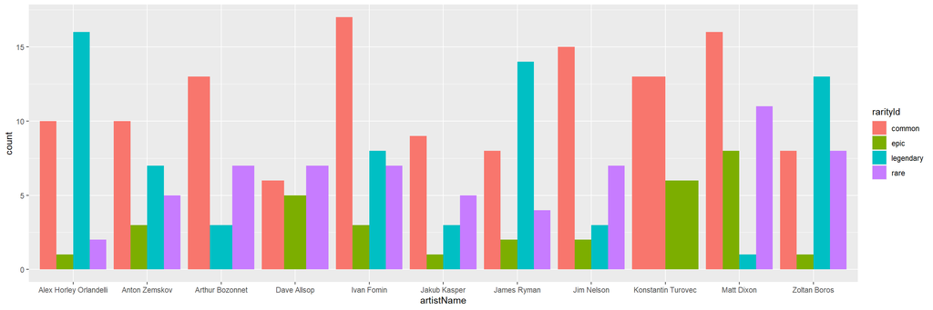

```r
ggplot(rarity,aes(artistName,..count..))+geom_bar(aes(fill=rarityId),position="dodge")
```

Legendary cards which are the most unique cards and the most important-gamechanger cards in the game are designed more by Alex Horley. Now let’s look for the class cards. In Hearthstone, there are 10 heroes which have unique hero power and special cards. Now let’s examine if artists involved more likely to design cards for the specific hero or not.

```r
heroes<-artists_10%>%select(artistName,classId)
heroes$classId<-as.factor(heroes$classId)

heroes$classId<-recode(heroes$classId,"14"="demonh","2"="druid","3"="hunter","4"="mage","5"="paladin","6"="priest","7"="rogue","8"="shaman","9"="warlock","10"="warrior","12"="neutral")
```

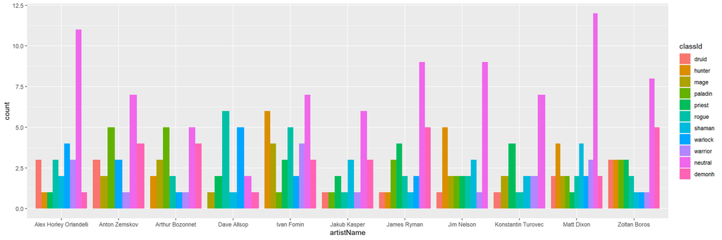

```r
ggplot(heroes,aes(artistName,..count..))+geom_bar(aes(fill=classId),position="dodge")
```

```r
res.aov <- chisq.test(heroes$artistName=="Alex Horley Orlandelli",heroes$classId, simulate.p.value = TRUE)
res.aov
```

```
##
##  Pearson's Chi-squared test with simulated p-value (based on 2000
##  replicates)
##
## data:  heroes$artistName == "Alex Horley Orlandelli" and heroes$classId
## X-squared = 12.977, df = NA, p-value = 0.2099
```

Due to the small cell sizes, all estimates will be inaccurate. It could be better to just use logistic regression or naive Bayes. But for now, it’s not a good idea to conduct such analyzing methods with this dataset. (I conducted for predicting artist names through the card rarities. But trust me, accuracy and Kappa values were too low even after the model fitting implementations)